| Augur Lake | Augur Lake Property Owners Association | Town(s) of Chesterfield | Essex County |
| --- | --- | --- | --- |

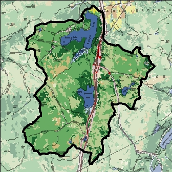

## Augur Lake – 2018 Sampling Season Results

Open Water Indicators

2018 Sampling Results

Seasonal Change

Season Avg

Decadal Average

Decadal Trend?

Longterm Avg

Longterm Trend?

06-03

06-17

07-01

07-16

07-29

08-13

08-27

09-09

Clarity (m)

4.8

3.5

3.5

3.1

4.2

5.5

3.9

2.9

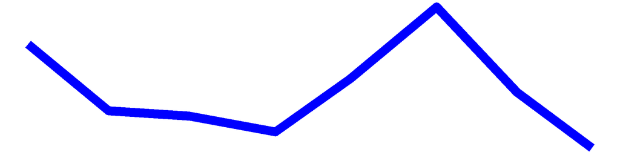

3.9

2.9

2.9

Surface TP (mg/L)

0.013

0.014

0.016

0.012

0.014

0.014

0.011

0.016

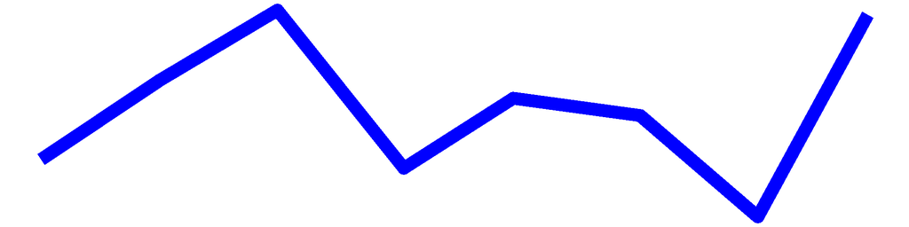

0.014

0.022

0.019

Surface TDP (mg/L)

0.004

0.008

0.008

0.007

0.002

0.006

0.009

0.005

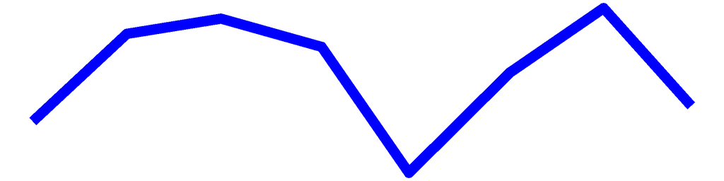

0.006

Deep TP (mg/L)

0.015

0.015

0.026

0.018

0.011

0.015

0.01

0.016

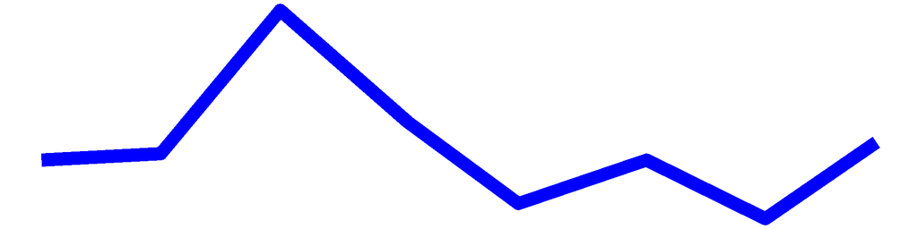

0.016

0.023

0.022

Deep TDP (mg/L)

0.009

0.007

0.014

0.018

0.002

0.007

0.006

0.005

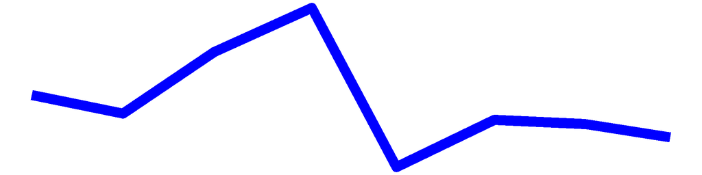

0.009

TN (mg/L)

0.215

0.303

0.395

0.268

0.458

0.289

0.415

0.538

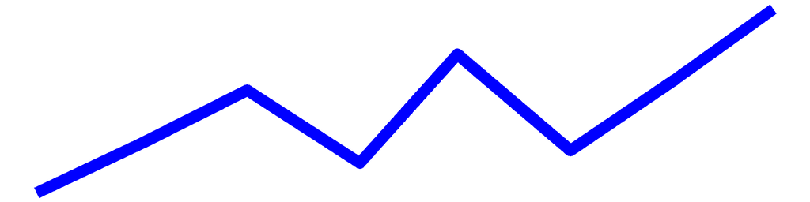

0.36

0.417

0.39

TDN (mg/L)

0.258

0.32

0.39

0.285

0.487

0.282

0.458

0.503

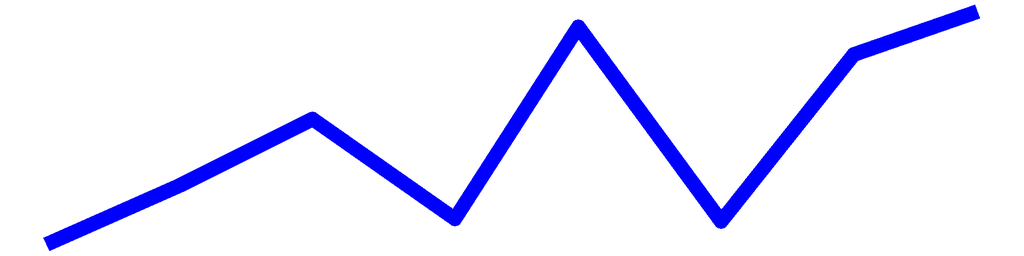

0.373

0.231

0.231

TN:TP

17

21

25

22

33

21

37

34

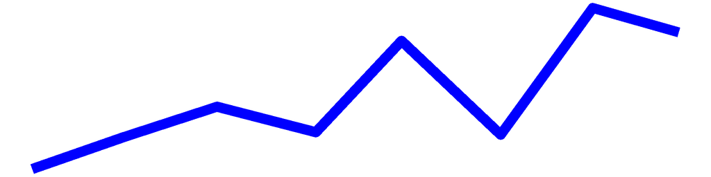

26

21

23

Surface NH3 (mg/L)

0.064

0.005

0.005

0.053

0.092

0.031

0.011

0.018

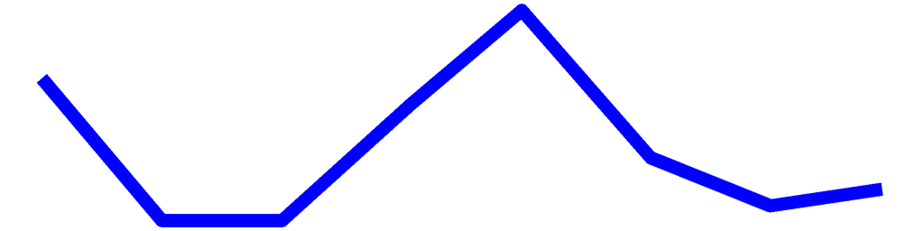

0.035

0.029

0.024

Deep NH3 (mg/L)

0.024

0.014

0.015

0.015

0.019

0.031

0.014

0.017

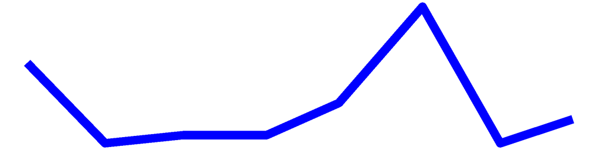

0.019

0.033

0.033

Chl.a (ug/L)

1.6

3.7

3.9

3.3

1.6

5.4

8.3

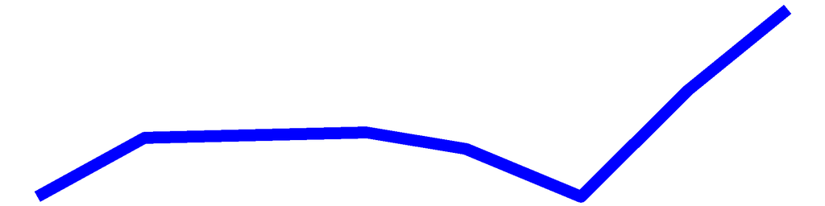

3.6

8.3

[figure not shown]

7.8

pH

7.8

8.1

8.1

8.1

7.8

7.8

8.2

7.2

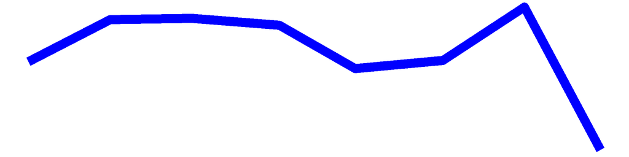

7.9

7.8

7.8

Cond (umho/cm)

164

249

243

225

249

272

235

268

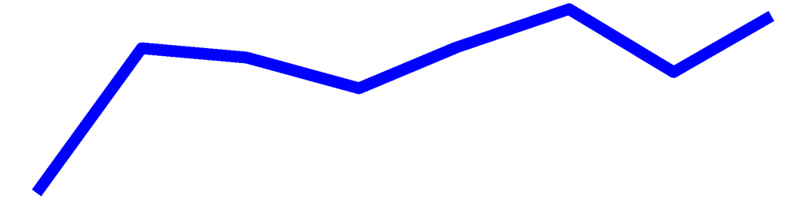

238

188

191

Surface Chloride (mg/L)

31

33

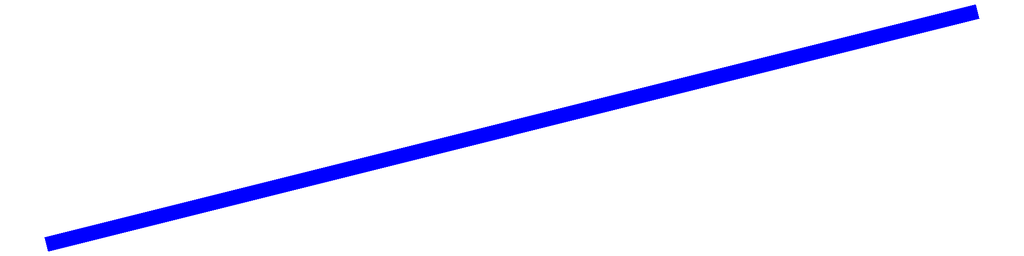

32

41

41

Upper Temp (degC)

22

22

26

27

25

27

24

22

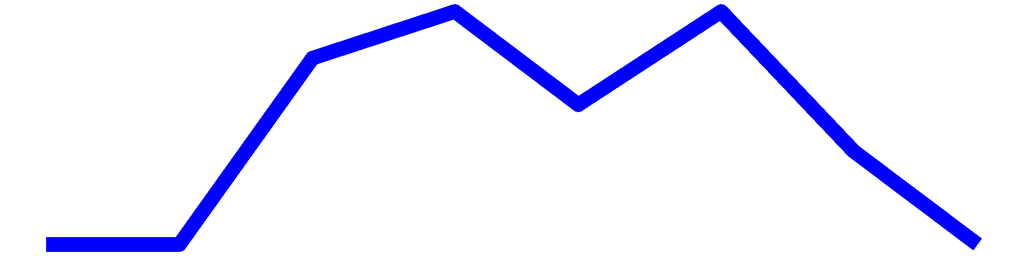

24

22

22

Deep Temp (degC)

21

22

23

24

25

25

23

22

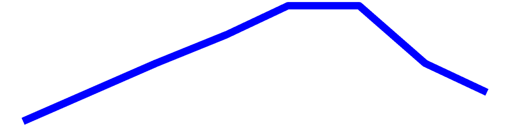

23

22

22

FP BG Chl.a (ug/L)

0.3

0.7

1.5

0.5

1.8

1

3.6

5.5

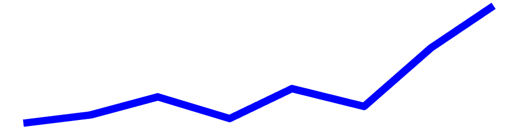

1.9

1.6

1.6

### NYHABs notifications

#### Were there any reported HABs this season? **No.**

### Shoreline HAB Sample Dates 2018

There were no shoreline HAB samples taken this season.

### HABs Status

#### Open Water Algae

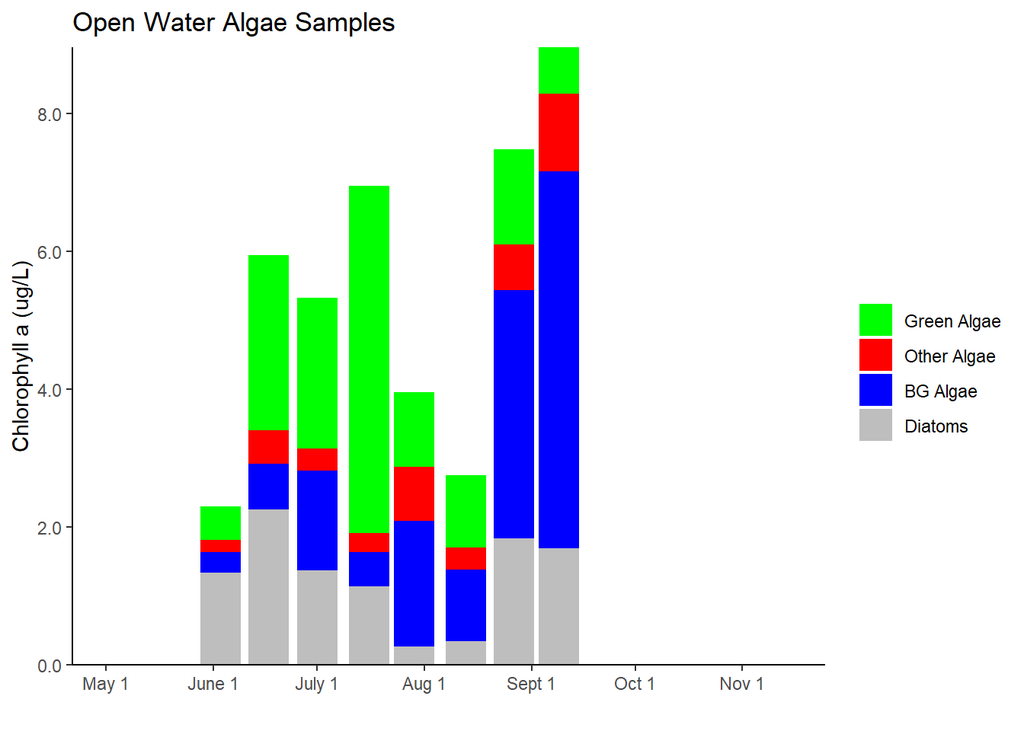

## Augur Lake Long-Term Trend Analysis

#### Clarity

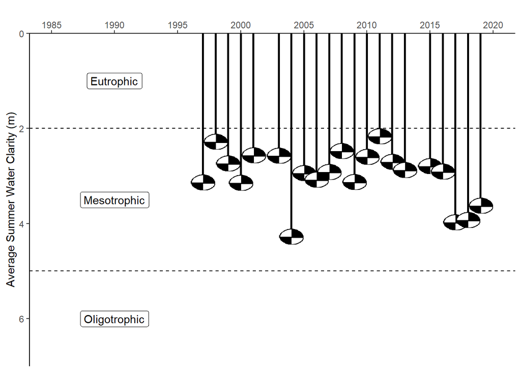

#### Chlorophyll *a*

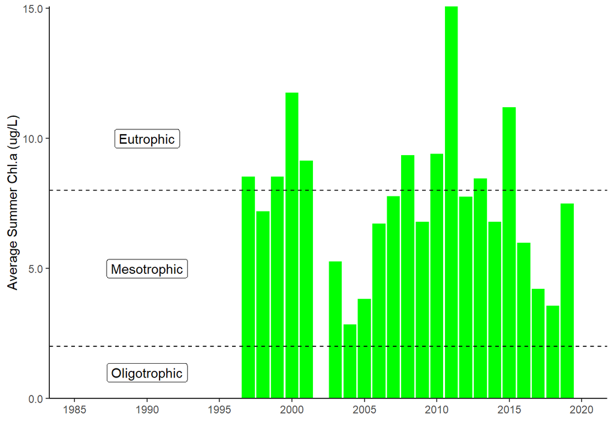

#### Surface and Deep Phosphorus

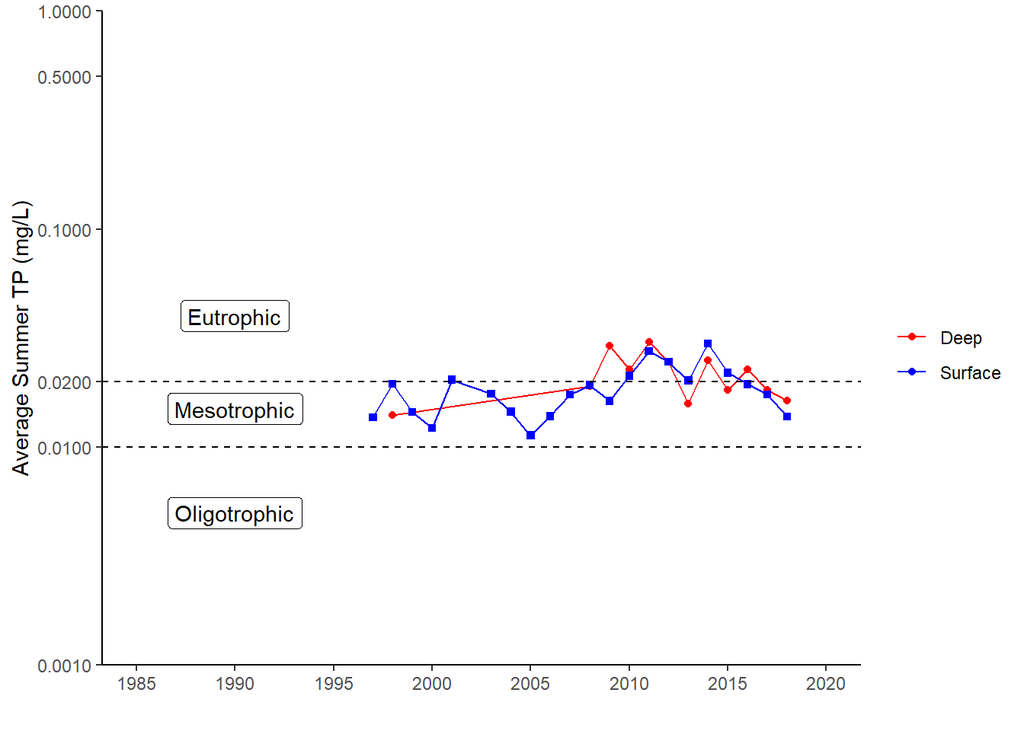

#### Nitrogen

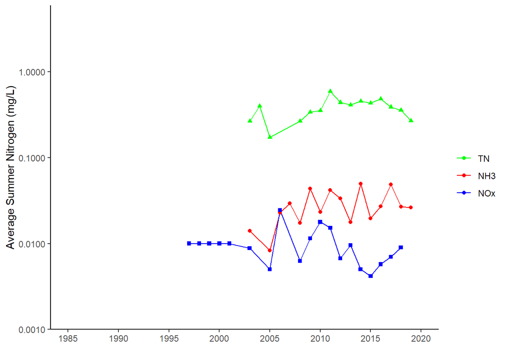

#### TN : TP

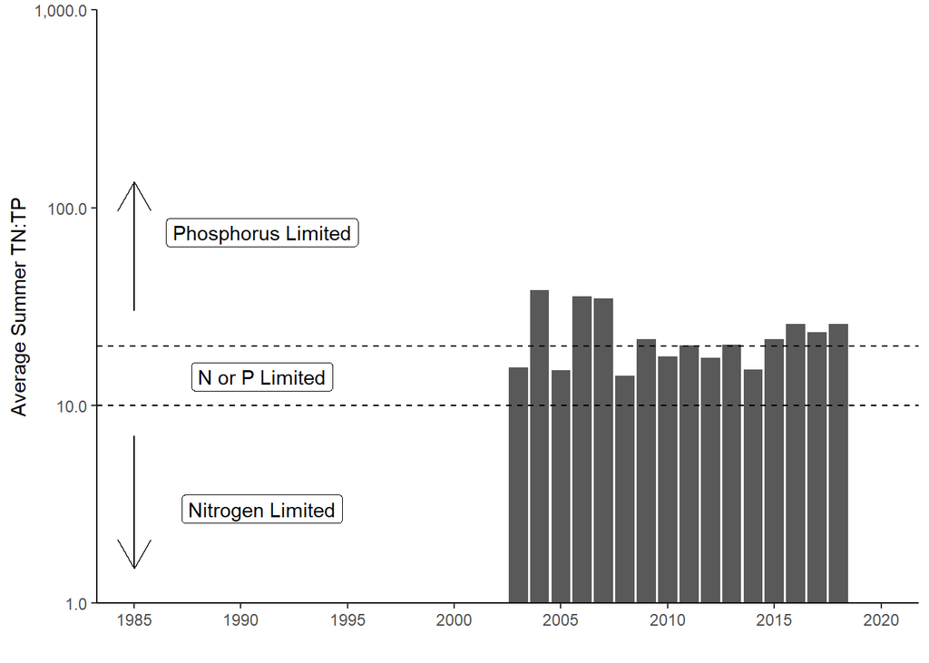

#### pH

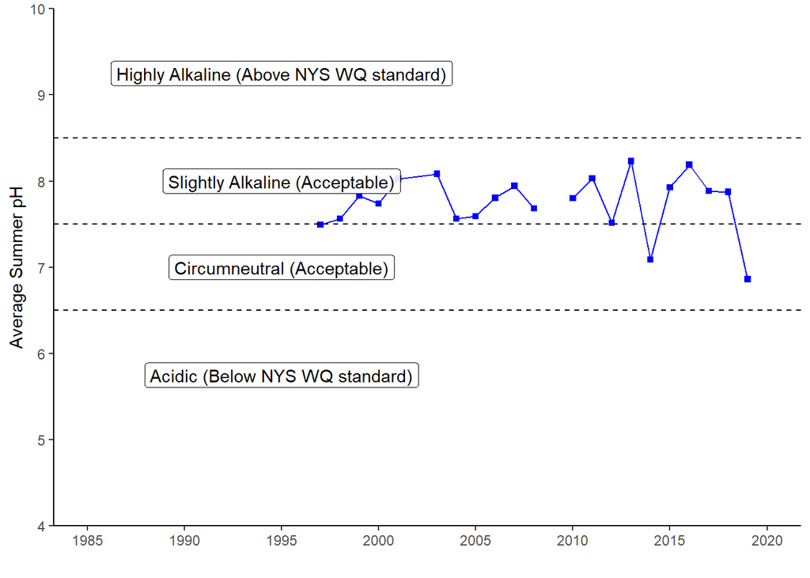

#### Specific Conductance

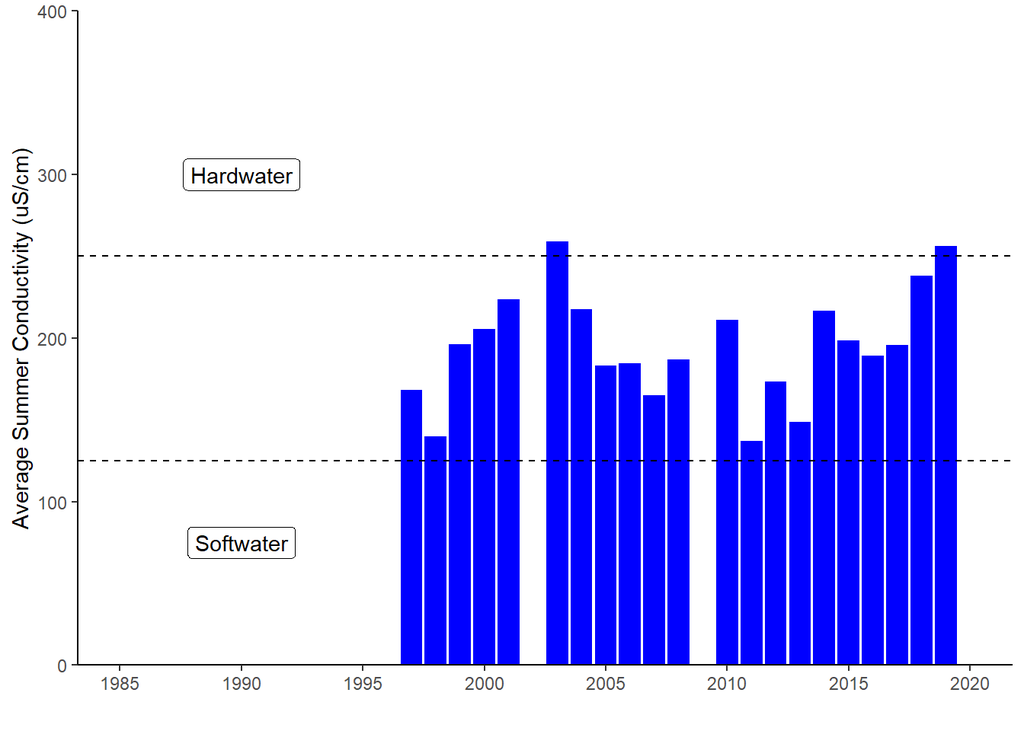

#### Calcium

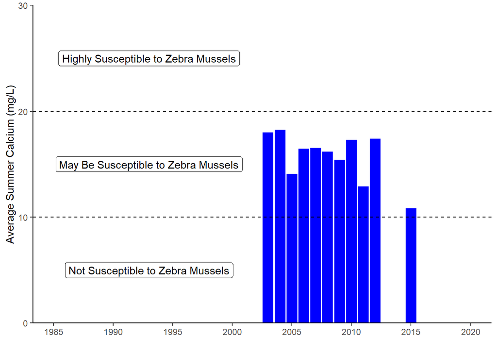

#### Chloride

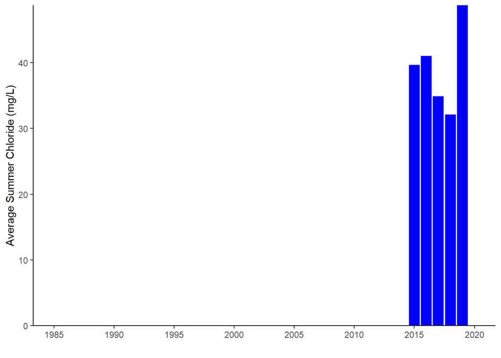

#### Color

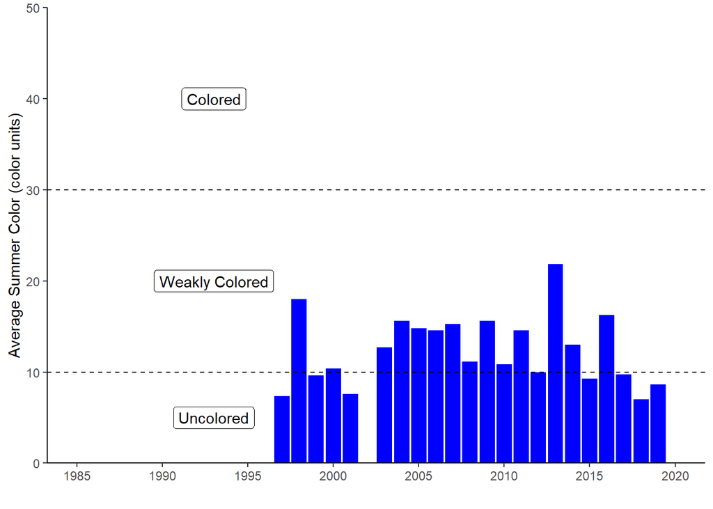

#### Surface and Deep Temperature

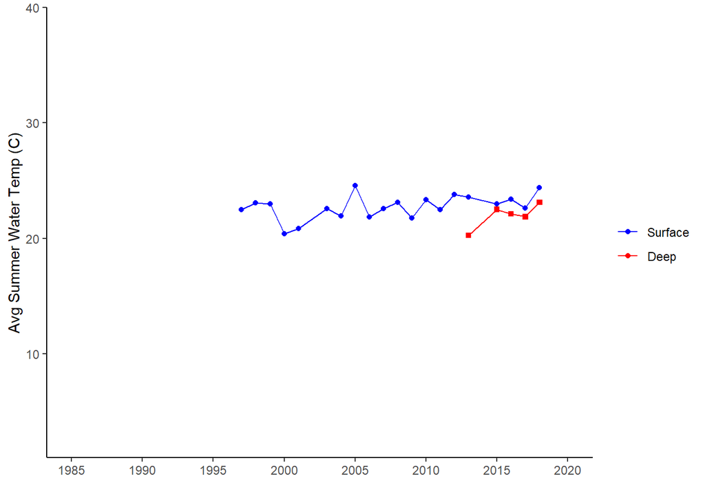

#### Lake Perception

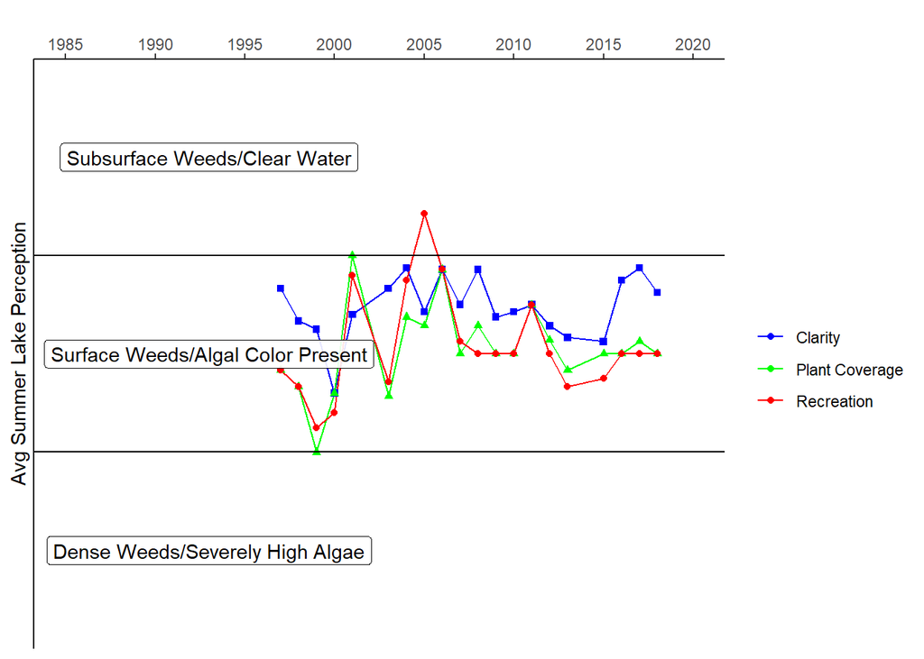